# Lab Four: GAN Example Fixing

Xingming Qu, Bowei Tian

## 1. [10 points] Run the code from fchollet "as-is" to generate samples of frogs from CIFAR. Are the results subjectively satisfying? Explain.

In this lab, I will use car images in CIFAR10 becuase the shape of the car is easier to identify. So it is better to evaluate.

```python
import keras
from keras import layers
import numpy as np
from keras.preprocessing import image
latent_dim = 32
height = 32
width = 32
channels = 3

generator_input = keras.Input(shape=(latent_dim,))

# First, transform the input into a 16x16 128-channels feature map
x = layers.Dense(128 * 16 * 16)(generator_input)
x = layers.LeakyReLU()(x)
x = layers.Reshape((16, 16, 128))(x)

# Then, add a convolution layer
x = layers.Conv2D(256, 5, padding='same')(x)
x = layers.LeakyReLU()(x)

# Upsample to 32x32
x = layers.Conv2DTranspose(256, 4, strides=2, padding='same')(x)
x = layers.LeakyReLU()(x)

# Few more conv layers
x = layers.Conv2D(256, 5, padding='same')(x)
x = layers.LeakyReLU()(x)
x = layers.Conv2D(256, 5, padding='same')(x)
x = layers.LeakyReLU()(x)

# Produce a 32x32 1-channel feature map
x = layers.Conv2D(channels, 7, activation='tanh', padding='same')(x)
generator = keras.models.Model(generator_input, x)
generator.summary()

discriminator_input = layers.Input(shape=(height, width, channels))
x = layers.Conv2D(128, 3)(discriminator_input)
x = layers.LeakyReLU()(x)
x = layers.Conv2D(128, 4, strides=2)(x)
x = layers.LeakyReLU()(x)
x = layers.Conv2D(128, 4, strides=2)(x)
x = layers.LeakyReLU()(x)
x = layers.Conv2D(128, 4, strides=2)(x)
x = layers.LeakyReLU()(x)
x = layers.Flatten()(x)

# One dropout layer - important trick!
x = layers.Dropout(0.4)(x)

# Classification layer
x = layers.Dense(1, activation='sigmoid')(x)

discriminator = keras.models.Model(discriminator_input, x)
discriminator.summary()

# To stabilize training, we use learning rate decay
# and gradient clipping (by value) in the optimizer.
discriminator_optimizer = keras.optimizers.RMSprop(lr=0.0008, clipvalue=1.0, decay=1e-8)
discriminator.compile(optimizer=discriminator_optimizer, loss='binary_crossentropy')

# Set discriminator weights to non-trainable
# (will only apply to the `gan` model)
discriminator.trainable = False

gan_input = keras.Input(shape=(latent_dim,))
gan_output = discriminator(generator(gan_input))
gan = keras.models.Model(gan_input, gan_output)

gan_optimizer = keras.optimizers.RMSprop(lr=0.0004, clipvalue=1.0, decay=1e-8)
gan.compile(optimizer=gan_optimizer, loss='binary_crossentropy')
```

```
_________________________________________________________________
Layer (type)                 Output Shape              Param #
=================================================================
input_1 (InputLayer)         (None, 32)                0
_________________________________________________________________
dense_1 (Dense)              (None, 32768)             1081344
_________________________________________________________________
leaky_re_lu_1 (LeakyReLU)    (None, 32768)             0
_________________________________________________________________
reshape_1 (Reshape)          (None, 16, 16, 128)       0
_________________________________________________________________
conv2d_1 (Conv2D)            (None, 16, 16, 256)       819456
_________________________________________________________________
leaky_re_lu_2 (LeakyReLU)    (None, 16, 16, 256)       0
_________________________________________________________________
conv2d_transpose_1 (Conv2DTr (None, 32, 32, 256)       1048832
_________________________________________________________________
leaky_re_lu_3 (LeakyReLU)    (None, 32, 32, 256)       0
_________________________________________________________________
conv2d_2 (Conv2D)            (None, 32, 32, 256)       1638656
_________________________________________________________________
leaky_re_lu_4 (LeakyReLU)    (None, 32, 32, 256)       0
_________________________________________________________________
conv2d_3 (Conv2D)            (None, 32, 32, 256)       1638656
_________________________________________________________________
leaky_re_lu_5 (LeakyReLU)    (None, 32, 32, 256)       0
_________________________________________________________________
conv2d_4 (Conv2D)            (None, 32, 32, 3)         37635
=================================================================
Total params: 6,264,579
Trainable params: 6,264,579
Non-trainable params: 0
_________________________________________________________________
_________________________________________________________________
Layer (type)                 Output Shape              Param #
=================================================================
input_2 (InputLayer)         (None, 32, 32, 3)         0
_________________________________________________________________
conv2d_5 (Conv2D)            (None, 30, 30, 128)       3584
_________________________________________________________________
```

[output cut: 9 more lines]

```
_________________________________________________________________
conv2d_8 (Conv2D)            (None, 2, 2, 128)         262272
_________________________________________________________________
leaky_re_lu_9 (LeakyReLU)    (None, 2, 2, 128)         0
_________________________________________________________________
flatten_1 (Flatten)          (None, 512)               0
_________________________________________________________________
dropout_1 (Dropout)          (None, 512)               0
_________________________________________________________________
dense_2 (Dense)              (None, 1)                 513
=================================================================
Total params: 790,913
Trainable params: 790,913
Non-trainable params: 0
_________________________________________________________________
```

```python
%%time
import os
from keras.preprocessing import image

# Load CIFAR10 data
(x_train, y_train), (_, _) = keras.datasets.cifar10.load_data()

# Select frog images (class 6)
x_train = x_train[y_train.flatten() == 1]

# Normalize data
x_train = x_train.reshape(
    (x_train.shape[0],) + (height, width, channels)).astype('float32') / 255.

iterations = 10000
batch_size = 20
save_dir = 'gan_images/'

# Start training loop
start = 0
for step in range(iterations):
    # Sample random points in the latent space
    random_latent_vectors = np.random.normal(size=(batch_size, latent_dim))

    # Decode them to fake images
    generated_images = generator.predict(random_latent_vectors)

    # Combine them with real images
    stop = start + batch_size
    real_images = x_train[start: stop]
    combined_images = np.concatenate([generated_images, real_images])

    # Assemble labels discriminating real from fake images
    labels = np.concatenate([np.ones((batch_size, 1)),
                             np.zeros((batch_size, 1))])
    # Add random noise to the labels - important trick!
    labels += 0.05 * np.random.random(labels.shape)

    # Train the discriminator
    d_loss = discriminator.train_on_batch(combined_images, labels)

    # sample random points in the latent space
    random_latent_vectors = np.random.normal(size=(batch_size, latent_dim))

    # Assemble labels that say "all real images"
    misleading_targets = np.zeros((batch_size, 1))

    # Train the generator (via the gan model,
    # where the discriminator weights are frozen)
    a_loss = gan.train_on_batch(random_latent_vectors, misleading_targets)

    start += batch_size
    if start > len(x_train) - batch_size:
        start = 0

    # Occasionally save / plot
    if step % 1000 == 0:
        # Save model weights
        gan.save_weights('gan_original.h5')

        # Print metrics
        print('discriminator loss at step %s: %s' % (step, d_loss),end='  ')
        print('adversarial loss at step %s: %s' % (step, a_loss))

        # Save one generated image
        img = image.array_to_img(generated_images[0] * 255., scale=False)
        img.save(os.path.join(save_dir, 'generated_frog' + str(step) + '.png'))

        # Save one real image, for comparison
        img = image.array_to_img(real_images[0] * 255., scale=False)
        img.save(os.path.join(save_dir, 'real_frog' + str(step) + '.png'))
```

```
discriminator loss at step 0: 0.70965195  adversarial loss at step 0: 0.6836926
discriminator loss at step 1000: 0.70220315  adversarial loss at step 1000: 0.7538697
discriminator loss at step 2000: 0.6873239  adversarial loss at step 2000: 0.6895071
discriminator loss at step 3000: 0.69332683  adversarial loss at step 3000: 0.71431243
discriminator loss at step 4000: 0.6729915  adversarial loss at step 4000: 0.88800687
discriminator loss at step 5000: 0.68587625  adversarial loss at step 5000: 0.61300963
discriminator loss at step 6000: 0.6485326  adversarial loss at step 6000: 0.8194739
discriminator loss at step 7000: 0.6803158  adversarial loss at step 7000: 0.7490736
discriminator loss at step 8000: 0.7381865  adversarial loss at step 8000: 0.8048151
discriminator loss at step 9000: 0.6188932  adversarial loss at step 9000: 1.079467
CPU times: user 7min 28s, sys: 2min 25s, total: 9min 54s
Wall time: 10min 41s
```

```python
gan.load_weights('gan_original.h5')
```

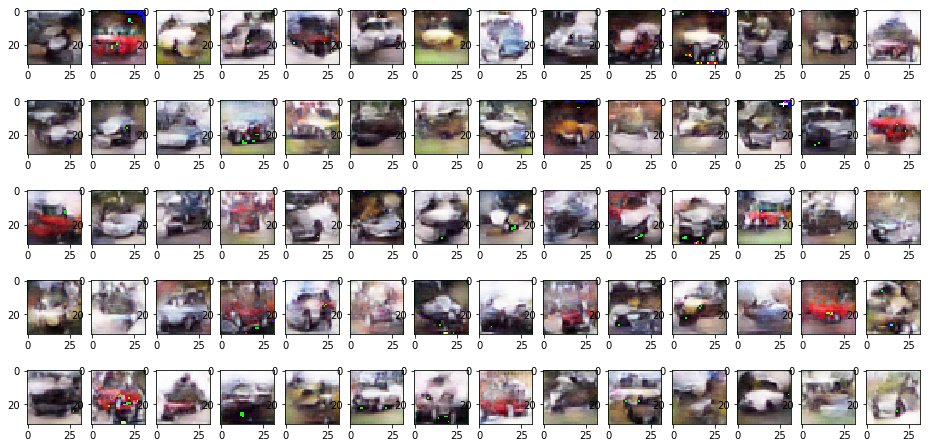

```python
import matplotlib.pyplot as plt
n_col=5
n_row=14
img_number=n_col*n_row
# Sample random points in the latent space
random_latent_vectors = np.random.normal(size=(img_number, latent_dim))

# Decode them to fake images
generated_images = generator.predict(random_latent_vectors)
plt.figure(figsize=(16,8))
for i in range(generated_images.shape[0]):
    plt.subplot(n_col, n_row, i + 1)
    img = image.array_to_img(generated_images[i] * 255., scale=False)
    plt.imshow(img)
plt.show()
```

Well, I think the result is not bad. At least at first glance I know these are cars. But the images still have a little artifacts. And it seems like there exist a little model collapse (the color of images look similar，silver cars are dominated).

## 2. [30 Points] Identify as many training issues from the Chollet notebook that could be improved upon. These could be "best practices" from the Tim Salimans paper (such as the use of one-sided label smoothing). Identify and explain what would need to be improved for potentially better results.

1. The architecture of generator and discriminator are not symmetrical  
   Solution: Make them to be symmetrical....use the symmetrical architecture  
   (But I question that should they really need to be symmetrical? GANs does not like auto encoders, they may not have to be symmetrical)
2. The kernel size is too big and should be consist all the time(for both generator and discriminator).  
   Solution: Use kernel size = 3 all the time
3. Add random noise to both fake and real images' label.  
   Solution: only add noise to fake images' label or using one-sided label smoothing from the Tim Salimans paper
4. Discriminator is not updating during training.  
   Solution: set discriminator.trainable = True before  
   d_loss = discriminator.train_on_batch(combined_images, labels)  
   Then set discriminator.trainable = True=False

## 3. [15 points] Fix one issue identified in your list and generate samples of CIFAR frogs. Choose the issue you believe to be most important. Subjectively, did this one change improve the generated results? Explain.

I believe the most important issue is 4: Discriminator is not updating during training. So the discriminator and generator are not adversarial during training. Therefore, generator could just generate simple images to fool the naive discriminator. So the Let's fix it.

```python
import keras
from keras import layers
import numpy as np

latent_dim = 32
height = 32
width = 32
channels = 3

generator_input = keras.Input(shape=(latent_dim,))

# First, transform the input into a 16x16 128-channels feature map
x = layers.Dense(128 * 16 * 16)(generator_input)
x = layers.LeakyReLU()(x)
x = layers.Reshape((16, 16, 128))(x)

# Then, add a convolution layer
x = layers.Conv2D(256, 5, padding='same')(x)
x = layers.LeakyReLU()(x)

# Upsample to 32x32
x = layers.Conv2DTranspose(256, 4, strides=2, padding='same')(x)
x = layers.LeakyReLU()(x)

# Few more conv layers
x = layers.Conv2D(256, 5, padding='same')(x)
x = layers.LeakyReLU()(x)
x = layers.Conv2D(256, 5, padding='same')(x)
x = layers.LeakyReLU()(x)

# Produce a 32x32 1-channel feature map
x = layers.Conv2D(channels, 7, activation='tanh', padding='same')(x)
generator = keras.models.Model(generator_input, x)
generator.summary()

discriminator_input = layers.Input(shape=(height, width, channels))
x = layers.Conv2D(128, 3)(discriminator_input)
x = layers.LeakyReLU()(x)
x = layers.Conv2D(128, 4, strides=2)(x)
x = layers.LeakyReLU()(x)
x = layers.Conv2D(128, 4, strides=2)(x)
x = layers.LeakyReLU()(x)
x = layers.Conv2D(128, 4, strides=2)(x)
x = layers.LeakyReLU()(x)
x = layers.Flatten()(x)

# One dropout layer - important trick!
x = layers.Dropout(0.4)(x)

# Classification layer
x = layers.Dense(1, activation='sigmoid')(x)

discriminator = keras.models.Model(discriminator_input, x)
discriminator.summary()

# To stabilize training, we use learning rate decay
# and gradient clipping (by value) in the optimizer.
discriminator_optimizer = keras.optimizers.RMSprop(lr=0.0008, clipvalue=1.0, decay=1e-8)
discriminator.compile(optimizer=discriminator_optimizer, loss='binary_crossentropy')

# Set discriminator weights to non-trainable
# (will only apply to the `gan` model)
discriminator.trainable = False

gan_input = keras.Input(shape=(latent_dim,))
gan_output = discriminator(generator(gan_input))
gan = keras.models.Model(gan_input, gan_output)

gan_optimizer = keras.optimizers.RMSprop(lr=0.0004, clipvalue=1.0, decay=1e-8)
gan.compile(optimizer=gan_optimizer, loss='binary_crossentropy')
```

```
_________________________________________________________________
Layer (type)                 Output Shape              Param #
=================================================================
input_4 (InputLayer)         (None, 32)                0
_________________________________________________________________
dense_3 (Dense)              (None, 32768)             1081344
_________________________________________________________________
leaky_re_lu_10 (LeakyReLU)   (None, 32768)             0
_________________________________________________________________
reshape_2 (Reshape)          (None, 16, 16, 128)       0
_________________________________________________________________
conv2d_9 (Conv2D)            (None, 16, 16, 256)       819456
_________________________________________________________________
leaky_re_lu_11 (LeakyReLU)   (None, 16, 16, 256)       0
_________________________________________________________________
conv2d_transpose_2 (Conv2DTr (None, 32, 32, 256)       1048832
_________________________________________________________________
leaky_re_lu_12 (LeakyReLU)   (None, 32, 32, 256)       0
_________________________________________________________________
conv2d_10 (Conv2D)           (None, 32, 32, 256)       1638656
_________________________________________________________________
leaky_re_lu_13 (LeakyReLU)   (None, 32, 32, 256)       0
_________________________________________________________________
conv2d_11 (Conv2D)           (None, 32, 32, 256)       1638656
_________________________________________________________________
leaky_re_lu_14 (LeakyReLU)   (None, 32, 32, 256)       0
_________________________________________________________________
conv2d_12 (Conv2D)           (None, 32, 32, 3)         37635
=================================================================
Total params: 6,264,579
Trainable params: 6,264,579
Non-trainable params: 0
_________________________________________________________________
_________________________________________________________________
Layer (type)                 Output Shape              Param #
=================================================================
input_5 (InputLayer)         (None, 32, 32, 3)         0
_________________________________________________________________
conv2d_13 (Conv2D)           (None, 30, 30, 128)       3584
_________________________________________________________________
```

[output cut: 9 more lines]

```
_________________________________________________________________
conv2d_16 (Conv2D)           (None, 2, 2, 128)         262272
_________________________________________________________________
leaky_re_lu_18 (LeakyReLU)   (None, 2, 2, 128)         0
_________________________________________________________________
flatten_2 (Flatten)          (None, 512)               0
_________________________________________________________________
dropout_2 (Dropout)          (None, 512)               0
_________________________________________________________________
dense_4 (Dense)              (None, 1)                 513
=================================================================
Total params: 790,913
Trainable params: 790,913
Non-trainable params: 0
_________________________________________________________________
```

```python
%%time
import os
from keras.preprocessing import image

# Load CIFAR10 data
(x_train, y_train), (_, _) = keras.datasets.cifar10.load_data()

# Select frog images (class 6)
x_train = x_train[y_train.flatten() == 1]

# Normalize data
x_train = x_train.reshape(
    (x_train.shape[0],) + (height, width, channels)).astype('float32') / 255.

iterations = 10000
batch_size = 20
save_dir = 'gan_images/'

# Start training loop
start = 0
for step in range(iterations):
    # Sample random points in the latent space
    random_latent_vectors = np.random.normal(size=(batch_size, latent_dim))

    # Decode them to fake images
    generated_images = generator.predict(random_latent_vectors)

    # Combine them with real images
    stop = start + batch_size
    real_images = x_train[start: stop]
    combined_images = np.concatenate([generated_images, real_images])

    # Assemble labels discriminating real from fake images
    labels = np.concatenate([np.ones((batch_size, 1)),
                             np.zeros((batch_size, 1))])
    # Add random noise to the labels - important trick!
    labels += 0.05 * np.random.random(labels.shape)

#######################################FIX FIX FIX ###############################################################################
    # Train the discriminator
    discriminator.trainable = True
    d_loss = discriminator.train_on_batch(combined_images, labels)
    discriminator.trainable = False
#######################################FIX FIX FIX ###############################################################################

    # sample random points in the latent space
    random_latent_vectors = np.random.normal(size=(batch_size, latent_dim))

    # Assemble labels that say "all real images"
    misleading_targets = np.zeros((batch_size, 1))

    # Train the generator (via the gan model,
    # where the discriminator weights are frozen)
    a_loss = gan.train_on_batch(random_latent_vectors, misleading_targets)

    start += batch_size
    if start > len(x_train) - batch_size:
        start = 0

    # Occasionally save / plot
    if step % 1000 == 0:
        # Save model weights
        gan.save_weights('gan_trainable_true.h5')

        # Print metrics
        print('discriminator loss at step %s: %s' % (step, d_loss),end='  ')
        print('adversarial loss at step %s: %s' % (step, a_loss))

        # Save one generated image
        img = image.array_to_img(generated_images[0] * 255., scale=False)
        img.save(os.path.join(save_dir, 'generated_frog' + str(step) + '.png'))

        # Save one real image, for comparison
        img = image.array_to_img(real_images[0] * 255., scale=False)
        img.save(os.path.join(save_dir, 'real_frog' + str(step) + '.png'))
```

```
discriminator loss at step 0: 0.66905105  adversarial loss at step 0: 0.67118704
discriminator loss at step 1000: 0.69040096  adversarial loss at step 1000: 0.7717717
discriminator loss at step 2000: 0.7211932  adversarial loss at step 2000: 0.79961634
discriminator loss at step 3000: 0.68483007  adversarial loss at step 3000: 0.8794128
discriminator loss at step 4000: 0.71200293  adversarial loss at step 4000: 0.81429356
discriminator loss at step 5000: 0.6825182  adversarial loss at step 5000: 0.8044199
discriminator loss at step 6000: 0.6705092  adversarial loss at step 6000: 0.7539839
discriminator loss at step 7000: 0.6880252  adversarial loss at step 7000: 0.7612592
discriminator loss at step 8000: 0.70506376  adversarial loss at step 8000: 0.7360426
discriminator loss at step 9000: 0.7089798  adversarial loss at step 9000: 0.7772265
CPU times: user 7min 26s, sys: 2min 24s, total: 9min 51s
Wall time: 10min 39s
```

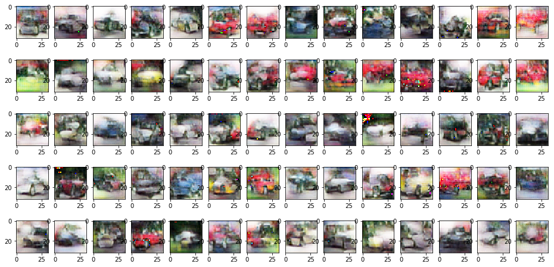

```python
import matplotlib.pyplot as plt
n_col=5
n_row=14
img_number=n_col*n_row
# Sample random points in the latent space
random_latent_vectors = np.random.normal(size=(img_number, latent_dim))

# Decode them to fake images
generated_images = generator.predict(random_latent_vectors)
plt.figure(figsize=(16,8))
for i in range(generated_images.shape[0]):
    plt.subplot(n_col, n_row, i + 1)
    img = image.array_to_img(generated_images[i] * 255., scale=False)
    plt.imshow(img)
plt.show()
```

I think this improved the result a little bit. Now we have less artifacts and GAN start to generate red, blue and yellow cars. Also, the quality of images seems improved a little.

## 4. [15 points] Fix another issue identified in your list and generate samples of CIFAR frogs. Choose the issue you believe to be NEXT most important. Subjectively, did this one change improve the generated results from the previous step? Explain.

The second important issus should be 1 and 2. Let's try to use kernel size =3 first but keep the asymmetrical net.

```python
import keras
from keras import layers
import numpy as np

latent_dim = 32
height = 32
width = 32
channels = 3

generator_input = keras.Input(shape=(latent_dim,))
#######################################FIX FIX FIX ###############################################################################
# First, transform the input into a 16x16 128-channels feature map
x = layers.Dense(128 * 16 * 16)(generator_input)
x = layers.LeakyReLU()(x)
x = layers.Reshape((16, 16, 128))(x)

# Then, add a convolution layer
x = layers.Conv2D(256, 3, padding='same')(x)
x = layers.LeakyReLU()(x)

# Upsample to 32x32
x = layers.Conv2DTranspose(256, 4, strides=2, padding='same')(x)
x = layers.LeakyReLU()(x)

# Few more conv layers
x = layers.Conv2D(256, 3, padding='same')(x)
x = layers.LeakyReLU()(x)
x = layers.Conv2D(256, 3, padding='same')(x)
x = layers.LeakyReLU()(x)

# Produce a 32x32 1-channel feature map
x = layers.Conv2D(channels, 3, activation='tanh', padding='same')(x)
generator = keras.models.Model(generator_input, x)
generator.summary()

discriminator_input = layers.Input(shape=(height, width, channels))
x = layers.Conv2D(128, 3)(discriminator_input)
x = layers.LeakyReLU()(x)
x = layers.Conv2D(128, 3, strides=2)(x)
x = layers.LeakyReLU()(x)
x = layers.Conv2D(128, 3, strides=2)(x)
x = layers.LeakyReLU()(x)
x = layers.Conv2D(128, 3, strides=2)(x)
x = layers.LeakyReLU()(x)
x = layers.Flatten()(x)
#######################################FIX FIX FIX ###############################################################################
# One dropout layer - important trick!
x = layers.Dropout(0.4)(x)

# Classification layer
x = layers.Dense(1, activation='sigmoid')(x)

discriminator = keras.models.Model(discriminator_input, x)
discriminator.summary()

# To stabilize training, we use learning rate decay
# and gradient clipping (by value) in the optimizer.
discriminator_optimizer = keras.optimizers.RMSprop(lr=0.0008, clipvalue=1.0, decay=1e-8)
discriminator.compile(optimizer=discriminator_optimizer, loss='binary_crossentropy')

# Set discriminator weights to non-trainable
# (will only apply to the `gan` model)
discriminator.trainable = False

gan_input = keras.Input(shape=(latent_dim,))
gan_output = discriminator(generator(gan_input))
gan = keras.models.Model(gan_input, gan_output)

gan_optimizer = keras.optimizers.RMSprop(lr=0.0004, clipvalue=1.0, decay=1e-8)
gan.compile(optimizer=gan_optimizer, loss='binary_crossentropy')
```

```
_________________________________________________________________
Layer (type)                 Output Shape              Param #
=================================================================
input_7 (InputLayer)         (None, 32)                0
_________________________________________________________________
dense_5 (Dense)              (None, 32768)             1081344
_________________________________________________________________
leaky_re_lu_19 (LeakyReLU)   (None, 32768)             0
_________________________________________________________________
reshape_3 (Reshape)          (None, 16, 16, 128)       0
_________________________________________________________________
conv2d_17 (Conv2D)           (None, 16, 16, 256)       295168
_________________________________________________________________
leaky_re_lu_20 (LeakyReLU)   (None, 16, 16, 256)       0
_________________________________________________________________
conv2d_transpose_3 (Conv2DTr (None, 32, 32, 256)       1048832
_________________________________________________________________
leaky_re_lu_21 (LeakyReLU)   (None, 32, 32, 256)       0
_________________________________________________________________
conv2d_18 (Conv2D)           (None, 32, 32, 256)       590080
_________________________________________________________________
leaky_re_lu_22 (LeakyReLU)   (None, 32, 32, 256)       0
_________________________________________________________________
conv2d_19 (Conv2D)           (None, 32, 32, 256)       590080
_________________________________________________________________
leaky_re_lu_23 (LeakyReLU)   (None, 32, 32, 256)       0
_________________________________________________________________
conv2d_20 (Conv2D)           (None, 32, 32, 3)         6915
=================================================================
Total params: 3,612,419
Trainable params: 3,612,419
Non-trainable params: 0
_________________________________________________________________
_________________________________________________________________
Layer (type)                 Output Shape              Param #
=================================================================
input_8 (InputLayer)         (None, 32, 32, 3)         0
_________________________________________________________________
conv2d_21 (Conv2D)           (None, 30, 30, 128)       3584
_________________________________________________________________
```

[output cut: 9 more lines]

```
_________________________________________________________________
conv2d_24 (Conv2D)           (None, 2, 2, 128)         147584
_________________________________________________________________
leaky_re_lu_27 (LeakyReLU)   (None, 2, 2, 128)         0
_________________________________________________________________
flatten_3 (Flatten)          (None, 512)               0
_________________________________________________________________
dropout_3 (Dropout)          (None, 512)               0
_________________________________________________________________
dense_6 (Dense)              (None, 1)                 513
=================================================================
Total params: 446,849
Trainable params: 446,849
Non-trainable params: 0
_________________________________________________________________
```

```python
%%time
import os
from keras.preprocessing import image

# Load CIFAR10 data
(x_train, y_train), (_, _) = keras.datasets.cifar10.load_data()

# Select frog images (class 6)
x_train = x_train[y_train.flatten() == 1]

# Normalize data
x_train = x_train.reshape(
    (x_train.shape[0],) + (height, width, channels)).astype('float32') / 255.

iterations = 10000
batch_size = 20
save_dir = 'gan_images/'

# Start training loop
start = 0
for step in range(iterations):
    # Sample random points in the latent space
    random_latent_vectors = np.random.normal(size=(batch_size, latent_dim))

    # Decode them to fake images
    generated_images = generator.predict(random_latent_vectors)

    # Combine them with real images
    stop = start + batch_size
    real_images = x_train[start: stop]
    combined_images = np.concatenate([generated_images, real_images])

    # Assemble labels discriminating real from fake images
    labels = np.concatenate([np.ones((batch_size, 1)),
                             np.zeros((batch_size, 1))])
    # Add random noise to the labels - important trick!
    labels += 0.05 * np.random.random(labels.shape)

    # Train the discriminator
    d_loss = discriminator.train_on_batch(combined_images, labels)

    # sample random points in the latent space
    random_latent_vectors = np.random.normal(size=(batch_size, latent_dim))

    # Assemble labels that say "all real images"
    misleading_targets = np.zeros((batch_size, 1))

    # Train the generator (via the gan model,
    # where the discriminator weights are frozen)
    a_loss = gan.train_on_batch(random_latent_vectors, misleading_targets)

    start += batch_size
    if start > len(x_train) - batch_size:
        start = 0

    # Occasionally save / plot
    if step % 1000 == 0:
        # Save model weights
        gan.save_weights('gan_kernel_size_eq_3.h5')

        # Print metrics
        print('discriminator loss at step %s: %s' % (step, d_loss),end='  ')
        print('adversarial loss at step %s: %s' % (step, a_loss))

        # Save one generated image
        img = image.array_to_img(generated_images[0] * 255., scale=False)
        img.save(os.path.join(save_dir, 'generated_frog' + str(step) + '.png'))

        # Save one real image, for comparison
        img = image.array_to_img(real_images[0] * 255., scale=False)
        img.save(os.path.join(save_dir, 'real_frog' + str(step) + '.png'))
```

```
discriminator loss at step 0: 0.6714142  adversarial loss at step 0: 0.6803652
discriminator loss at step 1000: 0.6875432  adversarial loss at step 1000: 0.73531103
discriminator loss at step 2000: 0.6922184  adversarial loss at step 2000: 0.8505743
discriminator loss at step 3000: 0.7058235  adversarial loss at step 3000: 0.74671
discriminator loss at step 4000: 0.69123584  adversarial loss at step 4000: 0.7594124
discriminator loss at step 5000: 0.6913237  adversarial loss at step 5000: 0.7504033
discriminator loss at step 6000: 0.6886576  adversarial loss at step 6000: 0.75304854
discriminator loss at step 7000: 0.69652224  adversarial loss at step 7000: 0.77643025
discriminator loss at step 8000: 0.69248194  adversarial loss at step 8000: 0.70274276
discriminator loss at step 9000: 0.71254957  adversarial loss at step 9000: 0.7551037
CPU times: user 5min 26s, sys: 1min 27s, total: 6min 53s
Wall time: 6min 52s
```

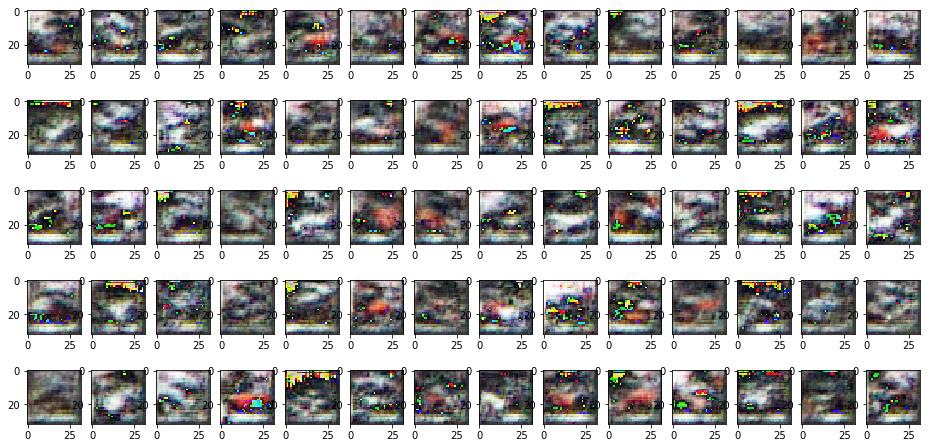

```python
import matplotlib.pyplot as plt
n_col=5
n_row=14
img_number=n_col*n_row
# Sample random points in the latent space
random_latent_vectors = np.random.normal(size=(img_number, latent_dim))

# Decode them to fake images
generated_images = generator.predict(random_latent_vectors)
plt.figure(figsize=(16,8))
for i in range(generated_images.shape[0]):
    plt.subplot(n_col, n_row, i + 1)
    img = image.array_to_img(generated_images[i] * 255., scale=False)
    plt.imshow(img)
plt.show()
```

Set all the kernel size = 3 is not a good method. It generates bad images with high model collapse and artifacts. So I think fchollet must have tried this and other different kernel size....that's why he chose the weird kernal size(but the result is good)

Next,let's try to make generator and discriminator symmetrical but use the orginal kernel size

```python
import keras
from keras import layers
import numpy as np
from keras.preprocessing import image
latent_dim = 32
height = 32
width = 32
channels = 3

generator_input = keras.Input(shape=(latent_dim,))
#######################################FIX FIX FIX ###############################################################################
# First, transform the input into a 16x16 128-channels feature map
x = layers.Dense(128 * 16 * 16)(generator_input)
x = layers.LeakyReLU()(x)
x = layers.Reshape((16, 16, 128))(x)

# Then, add a convolution layer
x = layers.Conv2D(256, 5, padding='same')(x)
x = layers.LeakyReLU()(x)

# Upsample to 32x32
x = layers.Conv2DTranspose(256, 4, strides=2, padding='same')(x)
x = layers.LeakyReLU()(x)

# Few more conv layers
x = layers.Conv2D(256, 5, padding='same')(x)
x = layers.LeakyReLU()(x)
x = layers.Conv2D(256, 5, padding='same')(x)
x = layers.LeakyReLU()(x)

# Produce a 32x32 1-channel feature map
x = layers.Conv2D(channels, 7, activation='tanh', padding='same')(x)
generator = keras.models.Model(generator_input, x)
generator.summary()

discriminator_input = layers.Input(shape=(height, width, channels))
x = layers.Conv2D(256, 3,padding='same')(discriminator_input)
x = layers.LeakyReLU()(x)
x = layers.Conv2D(256, 4, padding='same')(x)
x = layers.LeakyReLU()(x)
x = layers.Conv2D(256, 4, padding='same')(x)
x = layers.LeakyReLU()(x)
x = layers.Conv2D(256, 4, strides=2,padding='same')(x)
x = layers.LeakyReLU()(x)
x = layers.Conv2D(128, 4 ,padding='same')(x)
x = layers.LeakyReLU()(x)
x = layers.Flatten()(x)
#######################################FIX FIX FIX ###############################################################################
x= layers.Dense(32)(x)
# One dropout layer - important trick!
x = layers.Dropout(0.5)(x)

# Classification layer
x = layers.Dense(1, activation='sigmoid')(x)

discriminator = keras.models.Model(discriminator_input, x)
discriminator.summary()

# To stabilize training, we use learning rate decay
# and gradient clipping (by value) in the optimizer.
discriminator_optimizer = keras.optimizers.RMSprop(lr=0.0008, clipvalue=1.0, decay=1e-8)
discriminator.compile(optimizer=discriminator_optimizer, loss='binary_crossentropy')

# Set discriminator weights to non-trainable
# (will only apply to the `gan` model)
discriminator.trainable = False

gan_input = keras.Input(shape=(latent_dim,))
gan_output = discriminator(generator(gan_input))
gan = keras.models.Model(gan_input, gan_output)

gan_optimizer = keras.optimizers.RMSprop(lr=0.0004, clipvalue=1.0, decay=1e-8)
gan.compile(optimizer=gan_optimizer, loss='binary_crossentropy')
```

```
_________________________________________________________________
Layer (type)                 Output Shape              Param #
=================================================================
input_28 (InputLayer)        (None, 32)                0
_________________________________________________________________
dense_23 (Dense)             (None, 32768)             1081344
_________________________________________________________________
leaky_re_lu_83 (LeakyReLU)   (None, 32768)             0
_________________________________________________________________
reshape_10 (Reshape)         (None, 16, 16, 128)       0
_________________________________________________________________
conv2d_74 (Conv2D)           (None, 16, 16, 256)       819456
_________________________________________________________________
leaky_re_lu_84 (LeakyReLU)   (None, 16, 16, 256)       0
_________________________________________________________________
conv2d_transpose_10 (Conv2DT (None, 32, 32, 256)       1048832
_________________________________________________________________
leaky_re_lu_85 (LeakyReLU)   (None, 32, 32, 256)       0
_________________________________________________________________
conv2d_75 (Conv2D)           (None, 32, 32, 256)       1638656
_________________________________________________________________
leaky_re_lu_86 (LeakyReLU)   (None, 32, 32, 256)       0
_________________________________________________________________
conv2d_76 (Conv2D)           (None, 32, 32, 256)       1638656
_________________________________________________________________
leaky_re_lu_87 (LeakyReLU)   (None, 32, 32, 256)       0
_________________________________________________________________
conv2d_77 (Conv2D)           (None, 32, 32, 3)         37635
=================================================================
Total params: 6,264,579
Trainable params: 6,264,579
Non-trainable params: 0
_________________________________________________________________
_________________________________________________________________
Layer (type)                 Output Shape              Param #
=================================================================
input_29 (InputLayer)        (None, 32, 32, 3)         0
_________________________________________________________________
conv2d_78 (Conv2D)           (None, 32, 32, 256)       7168
_________________________________________________________________
```

[output cut: 15 more lines]

```
_________________________________________________________________
leaky_re_lu_92 (LeakyReLU)   (None, 16, 16, 128)       0
_________________________________________________________________
flatten_10 (Flatten)         (None, 32768)             0
_________________________________________________________________
dense_24 (Dense)             (None, 32)                1048608
_________________________________________________________________
dropout_10 (Dropout)         (None, 32)                0
_________________________________________________________________
dense_25 (Dense)             (None, 1)                 33
=================================================================
Total params: 4,726,721
Trainable params: 4,726,721
Non-trainable params: 0
_________________________________________________________________
```

Now the generator and discriminator are symmetrical

```python
%%time
import os
from keras.preprocessing import image

# Load CIFAR10 data
(x_train, y_train), (_, _) = keras.datasets.cifar10.load_data()

# Select frog images (class 6)
x_train = x_train[y_train.flatten() == 1]

# Normalize data
x_train = x_train.reshape(
    (x_train.shape[0],) + (height, width, channels)).astype('float32') / 255.

iterations = 10000
batch_size = 20
save_dir = 'gan_images/'

# Start training loop
start = 0
for step in range(iterations):
    # Sample random points in the latent space
    random_latent_vectors = np.random.normal(size=(batch_size, latent_dim))

    # Decode them to fake images
    generated_images = generator.predict(random_latent_vectors)

    # Combine them with real images
    stop = start + batch_size
    real_images = x_train[start: stop]
    combined_images = np.concatenate([generated_images, real_images])

    # Assemble labels discriminating real from fake images
    labels = np.concatenate([np.ones((batch_size, 1)),
                             np.zeros((batch_size, 1))])
    # Add random noise to the labels - important trick!
    labels += 0.05 * np.random.random(labels.shape)

    # Train the discriminator
    d_loss = discriminator.train_on_batch(combined_images, labels)

    # sample random points in the latent space
    random_latent_vectors = np.random.normal(size=(batch_size, latent_dim))

    # Assemble labels that say "all real images"
    misleading_targets = np.zeros((batch_size, 1))

    # Train the generator (via the gan model,
    # where the discriminator weights are frozen)
    a_loss = gan.train_on_batch(random_latent_vectors, misleading_targets)

    start += batch_size
    if start > len(x_train) - batch_size:
        start = 0

    # Occasionally save / plot
    if step % 1000 == 0:
        # Save model weights
        gan.save_weights('gan_fix_asymmetrical.h5')

        # Print metrics
        print('discriminator loss at step %s: %s' % (step, d_loss),end='  ')
        print('adversarial loss at step %s: %s' % (step, a_loss))

        # Save one generated image
        img = image.array_to_img(generated_images[0] * 255., scale=False)
        img.save(os.path.join(save_dir, 'generated_frog' + str(step) + '.png'))

        # Save one real image, for comparison
        img = image.array_to_img(real_images[0] * 255., scale=False)
        img.save(os.path.join(save_dir, 'real_frog' + str(step) + '.png'))
```

```
discriminator loss at step 0: 0.70705247  adversarial loss at step 0: 0.42554384
discriminator loss at step 1000: 8.438861  adversarial loss at step 1000: 1.0000001e-07
discriminator loss at step 2000: 8.49507  adversarial loss at step 2000: 1.0000001e-07
discriminator loss at step 3000: 8.43862  adversarial loss at step 3000: 1.0000001e-07
discriminator loss at step 4000: 8.46225  adversarial loss at step 4000: 1.0000001e-07
discriminator loss at step 5000: 8.457087  adversarial loss at step 5000: 1.0000001e-07
discriminator loss at step 6000: 8.472539  adversarial loss at step 6000: 1.0000001e-07
discriminator loss at step 7000: 8.474054  adversarial loss at step 7000: 1.0000001e-07
discriminator loss at step 8000: 8.46533  adversarial loss at step 8000: 1.0000001e-07
discriminator loss at step 9000: 8.5074215  adversarial loss at step 9000: 1.0000001e-07
CPU times: user 16min 24s, sys: 6min 10s, total: 22min 35s
Wall time: 29min 34s
```

We can see discriminator loss increased a lot while adversarial loss was all most 0. It means the generator dominated discriminator. I guess the reason is that we did not set discriminator to trainable. So let's fix it....

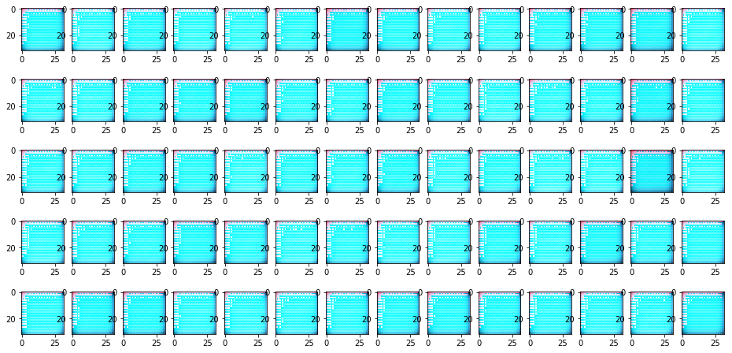

```python
import matplotlib.pyplot as plt
n_col=5
n_row=14
img_number=n_col*n_row
# Sample random points in the latent space
random_latent_vectors = np.random.normal(size=(img_number, latent_dim))

# Decode them to fake images
generated_images = generator.predict(random_latent_vectors)
plt.figure(figsize=(16,8))
for i in range(generated_images.shape[0]):
    plt.subplot(n_col, n_row, i + 1)
    img = image.array_to_img(generated_images[i] * 255., scale=False)
    plt.imshow(img)
plt.show()
```

Let's try set discriminator to trainable and keep the architecture symmetrical.

```python
import keras
from keras import layers
import numpy as np
from keras.preprocessing import image
latent_dim = 32
height = 32
width = 32
channels = 3

generator_input = keras.Input(shape=(latent_dim,))
#######################################FIX FIX FIX ###############################################################################
# First, transform the input into a 16x16 128-channels feature map
x = layers.Dense(128 * 16 * 16)(generator_input)
x = layers.LeakyReLU()(x)
x = layers.Reshape((16, 16, 128))(x)

# Then, add a convolution layer
x = layers.Conv2D(256, 5, padding='same')(x)
x = layers.LeakyReLU()(x)

# Upsample to 32x32
x = layers.Conv2DTranspose(256, 4, strides=2, padding='same')(x)
x = layers.LeakyReLU()(x)

# Few more conv layers
x = layers.Conv2D(256, 5, padding='same')(x)
x = layers.LeakyReLU()(x)
x = layers.Conv2D(256, 5, padding='same')(x)
x = layers.LeakyReLU()(x)

# Produce a 32x32 1-channel feature map
x = layers.Conv2D(channels, 7, activation='tanh', padding='same')(x)
generator = keras.models.Model(generator_input, x)
generator.summary()

discriminator_input = layers.Input(shape=(height, width, channels))
x = layers.Conv2D(256, 3,padding='same')(discriminator_input)
x = layers.LeakyReLU()(x)
x = layers.Conv2D(256, 4, padding='same')(x)
x = layers.LeakyReLU()(x)
x = layers.Conv2D(256, 4, padding='same')(x)
x = layers.LeakyReLU()(x)
x = layers.Conv2D(256, 4, strides=2,padding='same')(x)
x = layers.LeakyReLU()(x)
x = layers.Conv2D(128, 4 ,padding='same')(x)
x = layers.LeakyReLU()(x)
x = layers.Flatten()(x)
#######################################FIX FIX FIX ###############################################################################
x= layers.Dense(32)(x)
# One dropout layer - important trick!
x = layers.Dropout(0.5)(x)

# Classification layer
x = layers.Dense(1, activation='sigmoid')(x)

discriminator = keras.models.Model(discriminator_input, x)
discriminator.summary()

# To stabilize training, we use learning rate decay
# and gradient clipping (by value) in the optimizer.
discriminator_optimizer = keras.optimizers.RMSprop(lr=0.0008, clipvalue=1.0, decay=1e-8)
discriminator.compile(optimizer=discriminator_optimizer, loss='binary_crossentropy')

# Set discriminator weights to non-trainable
# (will only apply to the `gan` model)
discriminator.trainable = False

gan_input = keras.Input(shape=(latent_dim,))
gan_output = discriminator(generator(gan_input))
gan = keras.models.Model(gan_input, gan_output)

gan_optimizer = keras.optimizers.RMSprop(lr=0.0004, clipvalue=1.0, decay=1e-8)
gan.compile(optimizer=gan_optimizer, loss='binary_crossentropy')
```

```
_________________________________________________________________
Layer (type)                 Output Shape              Param #
=================================================================
input_31 (InputLayer)        (None, 32)                0
_________________________________________________________________
dense_26 (Dense)             (None, 32768)             1081344
_________________________________________________________________
leaky_re_lu_93 (LeakyReLU)   (None, 32768)             0
_________________________________________________________________
reshape_11 (Reshape)         (None, 16, 16, 128)       0
_________________________________________________________________
conv2d_83 (Conv2D)           (None, 16, 16, 256)       819456
_________________________________________________________________
leaky_re_lu_94 (LeakyReLU)   (None, 16, 16, 256)       0
_________________________________________________________________
conv2d_transpose_11 (Conv2DT (None, 32, 32, 256)       1048832
_________________________________________________________________
leaky_re_lu_95 (LeakyReLU)   (None, 32, 32, 256)       0
_________________________________________________________________
conv2d_84 (Conv2D)           (None, 32, 32, 256)       1638656
_________________________________________________________________
leaky_re_lu_96 (LeakyReLU)   (None, 32, 32, 256)       0
_________________________________________________________________
conv2d_85 (Conv2D)           (None, 32, 32, 256)       1638656
_________________________________________________________________
leaky_re_lu_97 (LeakyReLU)   (None, 32, 32, 256)       0
_________________________________________________________________
conv2d_86 (Conv2D)           (None, 32, 32, 3)         37635
=================================================================
Total params: 6,264,579
Trainable params: 6,264,579
Non-trainable params: 0
_________________________________________________________________
_________________________________________________________________
Layer (type)                 Output Shape              Param #
=================================================================
input_32 (InputLayer)        (None, 32, 32, 3)         0
_________________________________________________________________
conv2d_87 (Conv2D)           (None, 32, 32, 256)       7168
_________________________________________________________________
```

[output cut: 15 more lines]

```
_________________________________________________________________
leaky_re_lu_102 (LeakyReLU)  (None, 16, 16, 128)       0
_________________________________________________________________
flatten_11 (Flatten)         (None, 32768)             0
_________________________________________________________________
dense_27 (Dense)             (None, 32)                1048608
_________________________________________________________________
dropout_11 (Dropout)         (None, 32)                0
_________________________________________________________________
dense_28 (Dense)             (None, 1)                 33
=================================================================
Total params: 4,726,721
Trainable params: 4,726,721
Non-trainable params: 0
_________________________________________________________________
```

```python
%%time
import os
from keras.preprocessing import image

# Load CIFAR10 data
(x_train, y_train), (_, _) = keras.datasets.cifar10.load_data()

# Select frog images (class 6)
x_train = x_train[y_train.flatten() == 1]

# Normalize data
x_train = x_train.reshape(
    (x_train.shape[0],) + (height, width, channels)).astype('float32') / 255.

iterations = 10000
batch_size = 20
save_dir = 'gan_images/'

# Start training loop
start = 0
for step in range(iterations):
    # Sample random points in the latent space
    random_latent_vectors = np.random.normal(size=(batch_size, latent_dim))

    # Decode them to fake images
    generated_images = generator.predict(random_latent_vectors)

    # Combine them with real images
    stop = start + batch_size
    real_images = x_train[start: stop]
    combined_images = np.concatenate([generated_images, real_images])

    # Assemble labels discriminating real from fake images
    labels = np.concatenate([np.ones((batch_size, 1)),
                             np.zeros((batch_size, 1))])
    # Add random noise to the labels - important trick!
    labels += 0.05 * np.random.random(labels.shape)

#######################################FIX FIX FIX ###############################################################################
    # Train the discriminator
    discriminator.trainable = True
    d_loss = discriminator.train_on_batch(combined_images, labels)
    discriminator.trainable = False
#######################################FIX FIX FIX ###############################################################################

    # sample random points in the latent space
    random_latent_vectors = np.random.normal(size=(batch_size, latent_dim))

    # Assemble labels that say "all real images"
    misleading_targets = np.zeros((batch_size, 1))

    # Train the generator (via the gan model,
    # where the discriminator weights are frozen)
    a_loss = gan.train_on_batch(random_latent_vectors, misleading_targets)

    start += batch_size
    if start > len(x_train) - batch_size:
        start = 0

    # Occasionally save / plot
    if step % 1000 == 0:
        # Save model weights
        gan.save_weights('gan_symmetrical_trainable_true.h5')

        # Print metrics
        print('discriminator loss at step %s: %s' % (step, d_loss),end='  ')
        print('adversarial loss at step %s: %s' % (step, a_loss))

        # Save one generated image
        img = image.array_to_img(generated_images[0] * 255., scale=False)
        img.save(os.path.join(save_dir, 'generated_frog' + str(step) + '.png'))

        # Save one real image, for comparison
        img = image.array_to_img(real_images[0] * 255., scale=False)
        img.save(os.path.join(save_dir, 'real_frog' + str(step) + '.png'))
```

```
discriminator loss at step 0: 0.68409216  adversarial loss at step 0: 0.0006737133
discriminator loss at step 1000: 8.537693  adversarial loss at step 1000: 1.0000001e-07
discriminator loss at step 2000: 8.469832  adversarial loss at step 2000: 1.0000001e-07
discriminator loss at step 3000: 8.496624  adversarial loss at step 3000: 1.0000001e-07
discriminator loss at step 4000: 8.479403  adversarial loss at step 4000: 1.0000001e-07
discriminator loss at step 5000: 8.432962  adversarial loss at step 5000: 1.0000001e-07
discriminator loss at step 6000: 8.45554  adversarial loss at step 6000: 1.0000001e-07
discriminator loss at step 7000: 8.458384  adversarial loss at step 7000: 1.0000001e-07
discriminator loss at step 8000: 8.487955  adversarial loss at step 8000: 1.0000001e-07
discriminator loss at step 9000: 8.511099  adversarial loss at step 9000: 1.0000001e-07
CPU times: user 16min 26s, sys: 6min 11s, total: 22min 37s
Wall time: 29min 37s
```

Still, it did not work...I believe the reason is that after flattern there are 32768 neurons and we reduce it to 32. So lots of infomation lost.

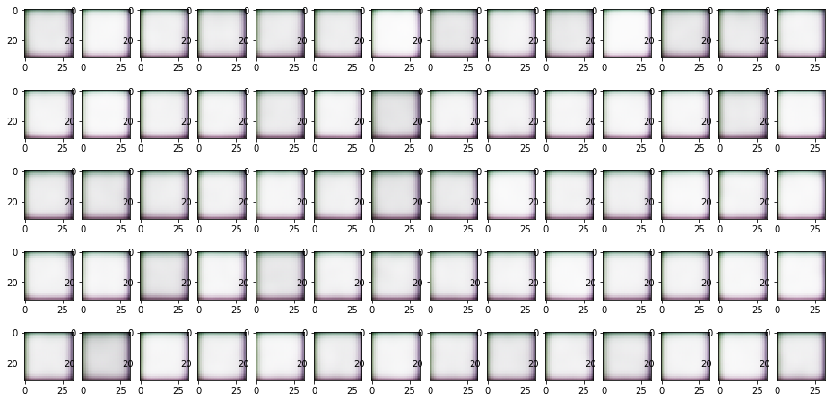

```python
import matplotlib.pyplot as plt
n_col=5
n_row=14
img_number=n_col*n_row
# Sample random points in the latent space
random_latent_vectors = np.random.normal(size=(img_number, latent_dim))

# Decode them to fake images
generated_images = generator.predict(random_latent_vectors)
plt.figure(figsize=(16,8))
for i in range(generated_images.shape[0]):
    plt.subplot(n_col, n_row, i + 1)
    img = image.array_to_img(generated_images[i] * 255., scale=False)
    plt.imshow(img)
plt.show()
```

We actuall can not make it symmetrical. We need to reduce the dimension in the end of the network, or there will be too many neurons connect to one neurons.

## 5. [15 points] Fix another issue identified in your list and generate samples of CIFAR frogs. Choose the issue you believe to be NEXT most important. Subjectively, did this one change improve the generated results from the previous step? Explain.

```python
import keras
from keras import layers
import numpy as np

latent_dim = 32
height = 32
width = 32
channels = 3

generator_input = keras.Input(shape=(latent_dim,))

# First, transform the input into a 16x16 128-channels feature map
x = layers.Dense(128 * 16 * 16)(generator_input)
x = layers.LeakyReLU()(x)
x = layers.Reshape((16, 16, 128))(x)

# Then, add a convolution layer
x = layers.Conv2D(256, 5, padding='same')(x)
x = layers.LeakyReLU()(x)

# Upsample to 32x32
x = layers.Conv2DTranspose(256, 4, strides=2, padding='same')(x)
x = layers.LeakyReLU()(x)

# Few more conv layers
x = layers.Conv2D(256, 5, padding='same')(x)
x = layers.LeakyReLU()(x)
x = layers.Conv2D(256, 5, padding='same')(x)
x = layers.LeakyReLU()(x)

# Produce a 32x32 1-channel feature map
x = layers.Conv2D(channels, 7, activation='tanh', padding='same')(x)
generator = keras.models.Model(generator_input, x)
generator.summary()

discriminator_input = layers.Input(shape=(height, width, channels))
x = layers.Conv2D(128, 3)(discriminator_input)
x = layers.LeakyReLU()(x)
x = layers.Conv2D(128, 4, strides=2)(x)
x = layers.LeakyReLU()(x)
x = layers.Conv2D(128, 4, strides=2)(x)
x = layers.LeakyReLU()(x)
x = layers.Conv2D(128, 4, strides=2)(x)
x = layers.LeakyReLU()(x)
x = layers.Flatten()(x)

# One dropout layer - important trick!
x = layers.Dropout(0.4)(x)

# Classification layer
x = layers.Dense(1, activation='sigmoid')(x)

discriminator = keras.models.Model(discriminator_input, x)
discriminator.summary()

# To stabilize training, we use learning rate decay
# and gradient clipping (by value) in the optimizer.
discriminator_optimizer = keras.optimizers.RMSprop(lr=0.0008, clipvalue=1.0, decay=1e-8)
discriminator.compile(optimizer=discriminator_optimizer, loss='binary_crossentropy')

# Set discriminator weights to non-trainable
# (will only apply to the `gan` model)
discriminator.trainable = False

gan_input = keras.Input(shape=(latent_dim,))
gan_output = discriminator(generator(gan_input))
gan = keras.models.Model(gan_input, gan_output)

gan_optimizer = keras.optimizers.RMSprop(lr=0.0004, clipvalue=1.0, decay=1e-8)
gan.compile(optimizer=gan_optimizer, loss='binary_crossentropy')
```

```
_________________________________________________________________
Layer (type)                 Output Shape              Param #
=================================================================
input_13 (InputLayer)        (None, 32)                0
_________________________________________________________________
dense_9 (Dense)              (None, 32768)             1081344
_________________________________________________________________
leaky_re_lu_38 (LeakyReLU)   (None, 32768)             0
_________________________________________________________________
reshape_5 (Reshape)          (None, 16, 16, 128)       0
_________________________________________________________________
conv2d_34 (Conv2D)           (None, 16, 16, 256)       819456
_________________________________________________________________
leaky_re_lu_39 (LeakyReLU)   (None, 16, 16, 256)       0
_________________________________________________________________
conv2d_transpose_5 (Conv2DTr (None, 32, 32, 256)       1048832
_________________________________________________________________
leaky_re_lu_40 (LeakyReLU)   (None, 32, 32, 256)       0
_________________________________________________________________
conv2d_35 (Conv2D)           (None, 32, 32, 256)       1638656
_________________________________________________________________
leaky_re_lu_41 (LeakyReLU)   (None, 32, 32, 256)       0
_________________________________________________________________
conv2d_36 (Conv2D)           (None, 32, 32, 256)       1638656
_________________________________________________________________
leaky_re_lu_42 (LeakyReLU)   (None, 32, 32, 256)       0
_________________________________________________________________
conv2d_37 (Conv2D)           (None, 32, 32, 3)         37635
=================================================================
Total params: 6,264,579
Trainable params: 6,264,579
Non-trainable params: 0
_________________________________________________________________
_________________________________________________________________
Layer (type)                 Output Shape              Param #
=================================================================
input_14 (InputLayer)        (None, 32, 32, 3)         0
_________________________________________________________________
conv2d_38 (Conv2D)           (None, 30, 30, 128)       3584
_________________________________________________________________
```

[output cut: 9 more lines]

```
_________________________________________________________________
conv2d_41 (Conv2D)           (None, 2, 2, 128)         262272
_________________________________________________________________
leaky_re_lu_46 (LeakyReLU)   (None, 2, 2, 128)         0
_________________________________________________________________
flatten_5 (Flatten)          (None, 512)               0
_________________________________________________________________
dropout_5 (Dropout)          (None, 512)               0
_________________________________________________________________
dense_10 (Dense)             (None, 1)                 513
=================================================================
Total params: 790,913
Trainable params: 790,913
Non-trainable params: 0
_________________________________________________________________
```

```python
%%time
import os
from keras.preprocessing import image

# Load CIFAR10 data
(x_train, y_train), (_, _) = keras.datasets.cifar10.load_data()

# Select frog images (class 6)
x_train = x_train[y_train.flatten() == 1]

# Normalize data
x_train = x_train.reshape(
    (x_train.shape[0],) + (height, width, channels)).astype('float32') / 255.

iterations = 10000
batch_size = 20
save_dir = 'gan_images/'

# Start training loop
start = 0
for step in range(iterations):
    # Sample random points in the latent space
    random_latent_vectors = np.random.normal(size=(batch_size, latent_dim))

    # Decode them to fake images
    generated_images = generator.predict(random_latent_vectors)

    # Combine them with real images
    stop = start + batch_size
    real_images = x_train[start: stop]
    combined_images = np.concatenate([generated_images, real_images])
#######################################FIX FIX FIX ###############################################################################
    # Assemble labels discriminating real from fake images
    labels = np.concatenate([np.ones((batch_size, 1))-0.1,
                             np.zeros((batch_size, 1))+0.1])
#     print(labels)
    # Add random noise to the labels - important trick!
#     labels += 0.05 * np.random.random(labels.shape)
#######################################FIX FIX FIX ###############################################################################
    # Train the discriminator
    d_loss = discriminator.train_on_batch(combined_images, labels)

    # sample random points in the latent space
    random_latent_vectors = np.random.normal(size=(batch_size, latent_dim))

    # Assemble labels that say "all real images"
    misleading_targets = np.zeros((batch_size, 1))

    # Train the generator (via the gan model,
    # where the discriminator weights are frozen)
    a_loss = gan.train_on_batch(random_latent_vectors, misleading_targets)

    start += batch_size
    if start > len(x_train) - batch_size:
        start = 0

    # Occasionally save / plot
    if step % 1000 == 0:
        # Save model weights
        gan.save_weights('gan_one-sided_smooth.h5')

        # Print metrics
        print('discriminator loss at step %s: %s' % (step, d_loss),end='  ')
        print('adversarial loss at step %s: %s' % (step, a_loss))

        # Save one generated image
        img = image.array_to_img(generated_images[0] * 255., scale=False)
        img.save(os.path.join(save_dir, 'generated_frog' + str(step) + '.png'))

        # Save one real image, for comparison
        img = image.array_to_img(real_images[0] * 255., scale=False)
        img.save(os.path.join(save_dir, 'real_frog' + str(step) + '.png'))
```

```
discriminator loss at step 0: 0.71180314  adversarial loss at step 0: 0.679206
discriminator loss at step 1000: 0.70906943  adversarial loss at step 1000: 0.7195802
discriminator loss at step 2000: 0.7052693  adversarial loss at step 2000: 0.71308255
discriminator loss at step 3000: 0.6906911  adversarial loss at step 3000: 0.69373274
discriminator loss at step 4000: 0.694455  adversarial loss at step 4000: 0.7163082
discriminator loss at step 5000: 0.69249177  adversarial loss at step 5000: 0.71185553
discriminator loss at step 6000: 0.7526296  adversarial loss at step 6000: 0.7887838
discriminator loss at step 7000: 0.6798893  adversarial loss at step 7000: 0.78897345
discriminator loss at step 8000: 0.7028513  adversarial loss at step 8000: 0.7254175
discriminator loss at step 9000: 0.68680793  adversarial loss at step 9000: 0.7403428
CPU times: user 7min 31s, sys: 2min 24s, total: 9min 55s
Wall time: 10min 43s
```

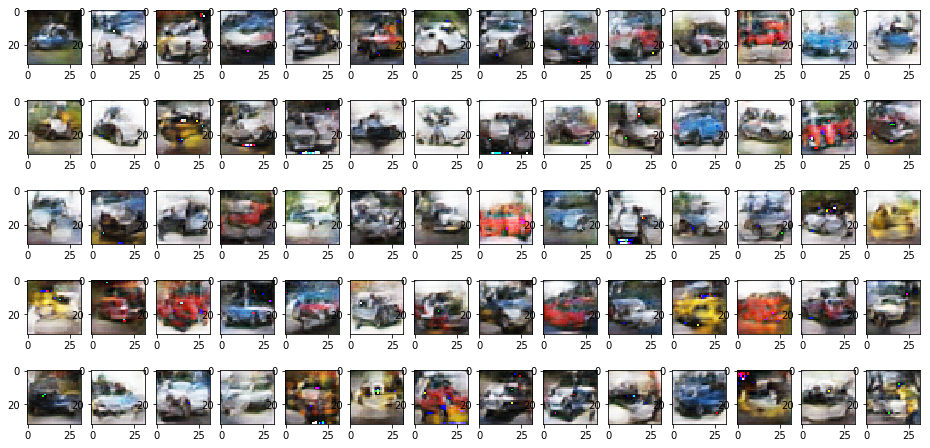

```python
import matplotlib.pyplot as plt
n_col=5
n_row=14
img_number=n_col*n_row
# Sample random points in the latent space
random_latent_vectors = np.random.normal(size=(img_number, latent_dim))

# Decode them to fake images
generated_images = generator.predict(random_latent_vectors)
plt.figure(figsize=(16,8))
for i in range(generated_images.shape[0]):
    plt.subplot(n_col, n_row, i + 1)
    img = image.array_to_img(generated_images[i] * 255., scale=False)
    plt.imshow(img)
plt.show()
```

WOW! The results are amazing. By just changing the label, we improved the quality of images and reduced model collapse!

## 6. [10 points] Exceptional work: Fix another issue identified in your list and generate samples of CIFAR frogs. Choose the issue you believe to be NEXT most important. Subjectively, did this one change improve the generated results from the previous step? Explain.

All right! Now it comes to conclusion:

```python
import keras
from keras import layers
import numpy as np

latent_dim = 32
height = 32
width = 32
channels = 3

generator_input = keras.Input(shape=(latent_dim,))

# First, transform the input into a 16x16 128-channels feature map
x = layers.Dense(128 * 16 * 16)(generator_input)
x = layers.LeakyReLU()(x)
x = layers.Reshape((16, 16, 128))(x)

# Then, add a convolution layer
x = layers.Conv2D(256, 5, padding='same')(x)
x = layers.LeakyReLU()(x)

# Upsample to 32x32
x = layers.Conv2DTranspose(256, 4, strides=2, padding='same')(x)
x = layers.LeakyReLU()(x)

# Few more conv layers
x = layers.Conv2D(256, 5, padding='same')(x)
x = layers.LeakyReLU()(x)
x = layers.Conv2D(256, 5, padding='same')(x)
x = layers.LeakyReLU()(x)

# Produce a 32x32 1-channel feature map
x = layers.Conv2D(channels, 7, activation='tanh', padding='same')(x)
generator = keras.models.Model(generator_input, x)
generator.summary()

discriminator_input = layers.Input(shape=(height, width, channels))
x = layers.Conv2D(128, 3)(discriminator_input)
x = layers.LeakyReLU()(x)
x = layers.Conv2D(128, 4,padding='same', strides=2)(x)
x = layers.LeakyReLU()(x)
x = layers.Conv2D(128, 4,padding='same', strides=2)(x)
x = layers.LeakyReLU()(x)
x = layers.Conv2D(128, 4,padding='same', strides=2)(x)
x = layers.LeakyReLU()(x)
x = layers.Flatten()(x)

# One dropout layer - important trick!
x = layers.Dropout(0.4)(x)

# Classification layer
x = layers.Dense(1, activation='sigmoid')(x)

discriminator = keras.models.Model(discriminator_input, x)
discriminator.summary()

# To stabilize training, we use learning rate decay
# and gradient clipping (by value) in the optimizer.
discriminator_optimizer = keras.optimizers.RMSprop(lr=0.0008, clipvalue=1.0, decay=1e-8)
discriminator.compile(optimizer=discriminator_optimizer, loss='binary_crossentropy')

# Set discriminator weights to non-trainable
# (will only apply to the `gan` model)
discriminator.trainable = False

gan_input = keras.Input(shape=(latent_dim,))
gan_output = discriminator(generator(gan_input))
gan = keras.models.Model(gan_input, gan_output)

gan_optimizer = keras.optimizers.RMSprop(lr=0.0004, clipvalue=1.0, decay=1e-8)
gan.compile(optimizer=gan_optimizer, loss='binary_crossentropy')
```

```
_________________________________________________________________
Layer (type)                 Output Shape              Param #
=================================================================
input_1 (InputLayer)         (None, 32)                0
_________________________________________________________________
dense_1 (Dense)              (None, 32768)             1081344
_________________________________________________________________
leaky_re_lu_1 (LeakyReLU)    (None, 32768)             0
_________________________________________________________________
reshape_1 (Reshape)          (None, 16, 16, 128)       0
_________________________________________________________________
conv2d_1 (Conv2D)            (None, 16, 16, 256)       819456
_________________________________________________________________
leaky_re_lu_2 (LeakyReLU)    (None, 16, 16, 256)       0
_________________________________________________________________
conv2d_transpose_1 (Conv2DTr (None, 32, 32, 256)       1048832
_________________________________________________________________
leaky_re_lu_3 (LeakyReLU)    (None, 32, 32, 256)       0
_________________________________________________________________
conv2d_2 (Conv2D)            (None, 32, 32, 256)       1638656
_________________________________________________________________
leaky_re_lu_4 (LeakyReLU)    (None, 32, 32, 256)       0
_________________________________________________________________
conv2d_3 (Conv2D)            (None, 32, 32, 256)       1638656
_________________________________________________________________
leaky_re_lu_5 (LeakyReLU)    (None, 32, 32, 256)       0
_________________________________________________________________
conv2d_4 (Conv2D)            (None, 32, 32, 3)         37635
=================================================================
Total params: 6,264,579
Trainable params: 6,264,579
Non-trainable params: 0
_________________________________________________________________
_________________________________________________________________
Layer (type)                 Output Shape              Param #
=================================================================
input_2 (InputLayer)         (None, 32, 32, 3)         0
_________________________________________________________________
conv2d_5 (Conv2D)            (None, 30, 30, 128)       3584
_________________________________________________________________
```

[output cut: 9 more lines]

```
_________________________________________________________________
conv2d_8 (Conv2D)            (None, 4, 4, 128)         262272
_________________________________________________________________
leaky_re_lu_9 (LeakyReLU)    (None, 4, 4, 128)         0
_________________________________________________________________
flatten_1 (Flatten)          (None, 2048)              0
_________________________________________________________________
dropout_1 (Dropout)          (None, 2048)              0
_________________________________________________________________
dense_2 (Dense)              (None, 1)                 2049
=================================================================
Total params: 792,449
Trainable params: 792,449
Non-trainable params: 0
_________________________________________________________________
```

```python
%%time
import os
from keras.preprocessing import image

# Load CIFAR10 data
(x_train, y_train), (_, _) = keras.datasets.cifar10.load_data()

# Select frog images (class 6)
x_train = x_train[y_train.flatten() == 1]

# Normalize data
x_train = x_train.reshape(
    (x_train.shape[0],) + (height, width, channels)).astype('float32') / 255.

iterations = 10000
batch_size = 20
save_dir = 'gan_images/'

# Start training loop
start = 0
for step in range(iterations):
    # Sample random points in the latent space
    random_latent_vectors = np.random.normal(size=(batch_size, latent_dim))

    # Decode them to fake images
    generated_images = generator.predict(random_latent_vectors)

    # Combine them with real images
    stop = start + batch_size
    real_images = x_train[start: stop]
    combined_images = np.concatenate([generated_images, real_images])

    # Assemble labels discriminating real from fake images
#     labels = np.concatenate([np.ones((batch_size, 1)),
#                              np.zeros((batch_size, 1))])
    labels = np.concatenate([np.ones((batch_size, 1))-0.1,
                             np.zeros((batch_size, 1))+0.1])
    # Add random noise to the labels - important trick!
#     labels += 0.05 * np.random.random(labels.shape)

######################################################################################################################
    # Train the discriminator
    discriminator.trainable = True
    d_loss = discriminator.train_on_batch(combined_images, labels)
    discriminator.trainable = False
######################################################################################################################

    # sample random points in the latent space
    random_latent_vectors = np.random.normal(size=(batch_size, latent_dim))

    # Assemble labels that say "all real images"
    misleading_targets = np.zeros((batch_size, 1))

    # Train the generator (via the gan model,
    # where the discriminator weights are frozen)
    a_loss = gan.train_on_batch(random_latent_vectors, misleading_targets)

    start += batch_size
    if start > len(x_train) - batch_size:
        start = 0

    # Occasionally save / plot
    if step % 1000 == 0:
        # Save model weights
        gan.save_weights('gan_combine_all_good_improvement.h5')

        # Print metrics
        print('discriminator loss at step %s: %s' % (step, d_loss),end='  ')
        print('adversarial loss at step %s: %s' % (step, a_loss))

        # Save one generated image
        img = image.array_to_img(generated_images[0] * 255., scale=False)
        img.save(os.path.join(save_dir, 'generated_frog' + str(step) + '.png'))

        # Save one real image, for comparison
        img = image.array_to_img(real_images[0] * 255., scale=False)
        img.save(os.path.join(save_dir, 'real_frog' + str(step) + '.png'))
```

```
discriminator loss at step 0: 0.6891116  adversarial loss at step 0: 0.66868174
discriminator loss at step 1000: 0.7053081  adversarial loss at step 1000: 0.69366276
discriminator loss at step 2000: 0.6910809  adversarial loss at step 2000: 0.69190156
discriminator loss at step 3000: 0.683288  adversarial loss at step 3000: 0.6839827
discriminator loss at step 4000: 0.6907324  adversarial loss at step 4000: 0.754814
discriminator loss at step 5000: 0.6896154  adversarial loss at step 5000: 0.6986598
discriminator loss at step 6000: 0.71002704  adversarial loss at step 6000: 0.7701556
discriminator loss at step 7000: 0.6942495  adversarial loss at step 7000: 0.7764591
discriminator loss at step 8000: 0.6942414  adversarial loss at step 8000: 0.909619
discriminator loss at step 9000: 0.69556016  adversarial loss at step 9000: 0.88499177
CPU times: user 7min 33s, sys: 2min 28s, total: 10min 1s
Wall time: 10min 50s
```

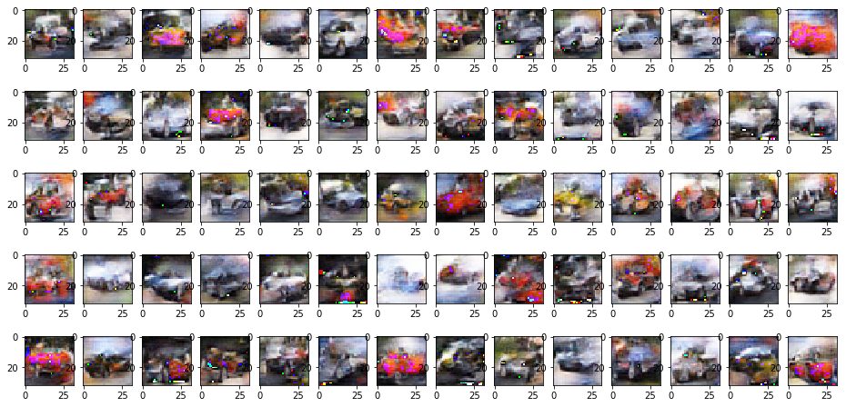

```python
import matplotlib.pyplot as plt
n_col=5
n_row=14
img_number=n_col*n_row
# Sample random points in the latent space
random_latent_vectors = np.random.normal(size=(img_number, latent_dim))

# Decode them to fake images
generated_images = generator.predict(random_latent_vectors)
plt.figure(figsize=(16,8))
for i in range(generated_images.shape[0]):
    plt.subplot(n_col, n_row, i + 1)
    img = image.array_to_img(generated_images[i] * 255., scale=False)
    plt.imshow(img)
plt.show()
```

Well,I personally think the results are not good as just using 3 and 4 separately. So it's very weird that both 3 and 4 improve results but it damage the result when using 3 and 4 together.

### Final results

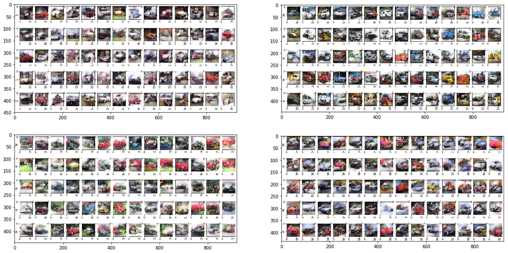

```python
folder='img'
plt.figure(figsize=(20,10))
it=0
for item in os.listdir(folder):
    path=os.path.join(folder,item)
    plt.subplot(2, 2, it + 1)
    img = image.load_img(path)
    plt.imshow(img)
    it=it+1
```

I think change the label is the best way to improve results...but it hard to tell which one is really better because the images were sooooo small...¯_(ツ)_/¯